# DS220 Final Project

### My main goal when analyzing this data is to determine what affects winning percentage in baseball the most. In order to do so, I am focusing on one specific team, the San Diego Padres in order to limit other factors that could come into play.

## Questions:

### How is OPS related to wins?

### How much can OPS vary for a certain number of wins?

### How is ERA related to wins?

### How much can OPS vary for a certain number of wins?

### How are OPS and ERA related?

### Have the OPS trends changed overtime?

### Have the ERA trends changed overtime?

The first two data sets were gathered from Kaggle.Com. The third data set was gathered from baeballrefernce.com.

```python
import pandas as pd
import matplotlib.pyplot as plt
import numpy as np
import seaborn as sns
data_batting=pd.read_csv("/content/SDP_batting.csv")
data_pitching=pd.read_csv("/content/SDP_pitching.csv")
wins_year=pd.read_csv("/content/Padres_Wins_By_Year.csv")
```

Through the use of ".columns",".head()", and ".tail()" we can see the variables present in the data frame. By looking at the column names, we are able to see that each individual row represents a single player's performance in a specific year. Each row then shows the year, the player's position, name, and age, and then their hitting stats.

```python
data_batting.columns
```

```
Index(['Rank', 'Year', 'Position', 'Name', 'Age', 'Games', 'Plate_Appearances',
       'At_Bats', 'Runs', 'Hits', 'Doubles', 'Triples', 'Home_Runs',
       'Runs_Batted_In', 'Stolen_Bases', 'Caught_Stealing', 'Base_On_Balls',
       'Strikeouts', 'Batting_Average', 'On_Base_Percentage',
       'Slugging_Percentage', 'On_Base_Plus_Slugging_Percentage',
       'On_Base_Plus_Slugging_Percentage_Plus', 'Total_Bases',
       'Double_Plays_Grounded_Into', 'Times_Hit_By_Pitch', 'Sacrifice_Hits',
       'Sacrifice_Flies', 'Intentional_Bases_on_Balls', 'Dominant_Hand',
       'Switch_Hitter'],
      dtype='object')
```

```python
data_batting.head()
```

|  | Rank | Year | Position | Name | Age | Games | Plate_Appearances | At_Bats | Runs | Hits | ... | On_Base_Plus_Slugging_Percentage | On_Base_Plus_Slugging_Percentage_Plus | Total_Bases | Double_Plays_Grounded_Into | Times_Hit_By_Pitch | Sacrifice_Hits | Sacrifice_Flies | Intentional_Bases_on_Balls | Dominant_Hand | Switch_Hitter |
| --- | --- | --- | --- | --- | --- | --- | --- | --- | --- | --- | --- | --- | --- | --- | --- | --- | --- | --- | --- | --- | --- |
| 0 | 1 | 2023 | C | Gary Sánchez | 30 | 72 | 260 | 234 | 33 | 51 | ... | 0.792 | 116 | 117 | 3 | 4 | 0 | 1 | 0 | Right | No |
| 1 | 2 | 2023 | 1B | Jake Cronenworth | 29 | 127 | 522 | 458 | 54 | 105 | ... | 0.689 | 92 | 173 | 8 | 11 | 1 | 5 | 2 | Left | No |
| 2 | 3 | 2023 | 2B | Ha-Seong Kim | 27 | 152 | 626 | 538 | 84 | 140 | ... | 0.749 | 110 | 214 | 7 | 3 | 5 | 5 | 1 | Right | No |
| 3 | 4 | 2023 | SS | Xander Bogaerts | 30 | 155 | 665 | 596 | 83 | 170 | ... | 0.790 | 120 | 262 | 21 | 7 | 0 | 6 | 0 | Right | No |
| 4 | 5 | 2023 | 3B | Manny Machado | 30 | 138 | 601 | 543 | 75 | 140 | ... | 0.782 | 115 | 251 | 20 | 2 | 0 | 6 | 1 | Right | No |

5 rows × 31 columns

```python
data_batting.tail()
```

|  | Rank | Year | Position | Name | Age | Games | Plate_Appearances | At_Bats | Runs | Hits | ... | On_Base_Plus_Slugging_Percentage | On_Base_Plus_Slugging_Percentage_Plus | Total_Bases | Double_Plays_Grounded_Into | Times_Hit_By_Pitch | Sacrifice_Hits | Sacrifice_Flies | Intentional_Bases_on_Balls | Dominant_Hand | Switch_Hitter |
| --- | --- | --- | --- | --- | --- | --- | --- | --- | --- | --- | --- | --- | --- | --- | --- | --- | --- | --- | --- | --- | --- |
| 2426 | 38 | 1969 | P | Leon Everitt | 22 | 6 | 4 | 3 | 0 | 0 | ... | 0.25 | -23 | 0 | 0 | 0 | 0 | 0 | 0 | Left | No |
| 2427 | 39 | 1969 | P | Steve Arlin | 23 | 4 | 2 | 2 | 0 | 0 | ... | 0.00 | -100 | 0 | 0 | 0 | 0 | 0 | 0 | Right | No |
| 2428 | 40 | 1969 | P | Al McBean | 31 | 1 | 2 | 2 | 0 | 1 | ... | 1.00 | 187 | 1 | 0 | 0 | 0 | 0 | 0 | Right | No |
| 2429 | 41 | 1969 | P | Billy McCool | 24 | 54 | 1 | 1 | 0 | 0 | ... | 0.00 | -100 | 0 | 0 | 0 | 0 | 0 | 0 | Right | No |
| 2430 | 42 | 1969 | P | Tom Dukes | 26 | 13 | 1 | 1 | 0 | 0 | ... | 0.00 | -100 | 0 | 0 | 0 | 0 | 0 | 0 | Right | No |

5 rows × 31 columns

Through the use of ".columns",".head()" and ".tail()" we can see the variables present in the data frame. By looking at the column names, we are able to see that each individual row represents a single player's performance in a specific year. Each row then shows the year, the player's position, name, and age, and then their pitching stats.

```python
data_pitching.columns
```

```
Index(['Rank', 'Year', 'Position', 'Name', 'Age', 'Wins', 'Losses',
       'Winning_Percentage', 'Earned_Run_Average', 'Games_Played',
       'Games_Started', 'Games_Finished', 'Complete_Games', 'Shutouts',
       'Saves', 'Innings_Pitched', 'Hits_Allowed', 'Runs_Allowed',
       'Earned_Runs', 'Home_Runs_Allowed', 'Walks_Allowed',
       'Intentional_Walks_Allowed', 'Strikeouts', 'Hit_By_Pitch', 'Balks',
       'Wild_Pitches', 'Batters_Faced', 'Adjusted_Earned_Run_Average',
       'Fielding_Independent_Pitching', 'Walks_Hits_Per_Inning_Pitched',
       'Hits_Per_Nine_Innings', 'Home_Runs_Per_Nine_Innings',
       'Walks_Per_Nine_Innings', 'Strikeouts_Per_Nine_Innings',
       'Strikeout_Walk_Ratio', 'Dominant_Hand', 'Switch_Hitter'],
      dtype='object')
```

```python
data_pitching = data_pitching[~data_pitching.isin([np.inf, -np.inf]).any(axis=1)]
```

```python
data_pitching.head()
```

|  | Rank | Year | Position | Name | Age | Wins | Losses | Winning_Percentage | Earned_Run_Average | Games_Played | ... | Adjusted_Earned_Run_Average | Fielding_Independent_Pitching | Walks_Hits_Per_Inning_Pitched | Hits_Per_Nine_Innings | Home_Runs_Per_Nine_Innings | Walks_Per_Nine_Innings | Strikeouts_Per_Nine_Innings | Strikeout_Walk_Ratio | Dominant_Hand | Switch_Hitter |
| --- | --- | --- | --- | --- | --- | --- | --- | --- | --- | --- | --- | --- | --- | --- | --- | --- | --- | --- | --- | --- | --- |
| 0 | 1 | 2023 | SP | Blake Snell | 30 | 14 | 9 | 0.609 | 2.25 | 32 | ... | 182 | 3.44 | 1.189 | 5.8 | 0.8 | 5.0 | 11.7 | 2.36 | Left | No |
| 1 | 2 | 2023 | SP | Seth Lugo | 33 | 8 | 7 | 0.533 | 3.57 | 26 | ... | 115 | 3.83 | 1.203 | 8.6 | 1.2 | 2.2 | 8.6 | 3.89 | Right | No |
| 2 | 3 | 2023 | SP | Yu Darvish | 36 | 8 | 10 | 0.444 | 4.56 | 24 | ... | 90 | 4.03 | 1.298 | 8.8 | 1.2 | 2.8 | 9.3 | 3.28 | Right | No |
| 3 | 4 | 2023 | SP | Michael Wacha | 31 | 14 | 4 | 0.778 | 3.22 | 24 | ... | 127 | 3.89 | 1.161 | 7.6 | 1.0 | 2.9 | 8.3 | 2.88 | Right | No |
| 4 | 5 | 2023 | SP | Joe Musgrove | 30 | 10 | 3 | 0.769 | 3.05 | 17 | ... | 134 | 3.52 | 1.140 | 8.3 | 0.9 | 1.9 | 9.0 | 4.62 | Right | No |

5 rows × 37 columns

```python
data_pitching.tail()
```

|  | Rank | Year | Position | Name | Age | Wins | Losses | Winning_Percentage | Earned_Run_Average | Games_Played | ... | Adjusted_Earned_Run_Average | Fielding_Independent_Pitching | Walks_Hits_Per_Inning_Pitched | Hits_Per_Nine_Innings | Home_Runs_Per_Nine_Innings | Walks_Per_Nine_Innings | Strikeouts_Per_Nine_Innings | Strikeout_Walk_Ratio | Dominant_Hand | Switch_Hitter |
| --- | --- | --- | --- | --- | --- | --- | --- | --- | --- | --- | --- | --- | --- | --- | --- | --- | --- | --- | --- | --- | --- |
| 1184 | 13 | 1969 | NaN | Dick Selma | 25 | 2 | 2 | 0.50 | 4.09 | 4 | ... | 88 | 3.69 | 1.273 | 7.8 | 1.2 | 3.7 | 8.2 | 2.22 | Right | No |
| 1185 | 14 | 1969 | NaN | Mike Corkins | 23 | 1 | 3 | 0.25 | 8.47 | 6 | ... | 43 | 4.69 | 2.059 | 14.3 | 1.6 | 4.2 | 6.9 | 1.63 | Right | No |
| 1186 | 15 | 1969 | NaN | Leon Everitt | 22 | 0 | 1 | 0.00 | 8.04 | 5 | ... | 45 | 6.91 | 1.915 | 10.3 | 2.3 | 6.9 | 6.3 | 0.92 | Right | No |
| 1187 | 16 | 1969 | NaN | Steve Arlin | 23 | 0 | 1 | 0.00 | 9.28 | 4 | ... | 40 | 5.79 | 2.063 | 11.0 | 1.7 | 7.6 | 7.6 | 1.00 | Right | No |
| 1188 | 17 | 1969 | NaN | Al McBean | 31 | 0 | 1 | 0.00 | 5.14 | 1 | ... | 73 | 4.94 | 1.714 | 12.9 | 1.3 | 2.6 | 1.3 | 0.50 | Right | No |

5 rows × 37 columns

```python
wins_year.head()
```

|  | Year | Tm | Lg | G | W | L | Ties | W-L% | pythW-L% | Finish | ... | Playoffs | R | RA | Attendance | BatAge | PAge | #Bat | #P | Top Player | Managers |
| --- | --- | --- | --- | --- | --- | --- | --- | --- | --- | --- | --- | --- | --- | --- | --- | --- | --- | --- | --- | --- | --- |
| 0 | 2024 | San Diego Padres | NL West | 27 | 14 | 13 | 0 | 0.519 | 0.537 | 2nd of 5 | ... | NaN | 130 | 120 | 538185.0 | 27.8 | 29.6 | 32 | 17 | D.Cease (0.9) | M.Shildt (14-13) |
| 1 | 2023 | San Diego Padres | NL West | 162 | 82 | 80 | 0 | 0.506 | 0.568 | 3rd of 5 | ... | NaN | 752 | 648 | 3271554.0 | 28.4 | 30.7 | 56 | 30 | B.Snell (6.2) | B.Melvin (82-80) |
| 2 | 2022 | San Diego Padres | NL West | 162 | 89 | 73 | 0 | 0.549 | 0.530 | 2nd of 5 | ... | Lost NLCS (4-1) | 705 | 660 | 2987470.0 | 28.2 | 30.3 | 55 | 30 | M.Machado (6.7) | B.Melvin (89-73) |
| 3 | 2021 | San Diego Padres | NL West | 162 | 79 | 83 | 0 | 0.488 | 0.513 | 3rd of 5 | ... | NaN | 729 | 708 | 2191950.0 | 28.0 | 29.6 | 54 | 34 | F.Tatís (6.6) | J.Tingler (79-83) |
| 4 | 2020 | San Diego Padres | NL West | 60 | 37 | 23 | 0 | 0.617 | 0.633 | 2nd of 5 | ... | Lost NLDS (3-0) | 325 | 241 | NaN | 26.7 | 27.8 | 47 | 24 | M.Machado (3.2) | J.Tingler (37-23) |

5 rows × 21 columns

```python
wins_year.tail()
```

|  | Year | Tm | Lg | G | W | L | Ties | W-L% | pythW-L% | Finish | ... | Playoffs | R | RA | Attendance | BatAge | PAge | #Bat | #P | Top Player | Managers |
| --- | --- | --- | --- | --- | --- | --- | --- | --- | --- | --- | --- | --- | --- | --- | --- | --- | --- | --- | --- | --- | --- |
| 51 | 1973 | San Diego Padres | NL West | 162 | 60 | 102 | 0 | 0.370 | 0.349 | 6th of 6 | ... | NaN | 548 | 770 | 611826.0 | 25.2 | 25.4 | 32 | 12 | D.Roberts (3.3) | D.Zimmer (60-102) |
| 52 | 1972 | San Diego Padres | NL West | 153 | 58 | 95 | 0 | 0.379 | 0.362 | 6th of 6 | ... | NaN | 488 | 665 | 644273.0 | 25.1 | 25.2 | 41 | 15 | N.Colbert (5.4) | P.Gómez (4-7) and D.Zimmer (54-88) |
| 53 | 1971 | San Diego Padres | NL West | 161 | 61 | 100 | 0 | 0.379 | 0.398 | 6th of 6 | ... | NaN | 486 | 610 | 557513.0 | 26.4 | 26.3 | 40 | 16 | D.Roberts (7.8) | P.Gómez (61-100) |
| 54 | 1970 | San Diego Padres | NL West | 162 | 63 | 99 | 0 | 0.389 | 0.434 | 6th of 6 | ... | NaN | 681 | 788 | 643679.0 | 26.6 | 26.4 | 37 | 16 | C.Gaston (5.1) | P.Gómez (63-99) |
| 55 | 1969 | San Diego Padres | NL West | 162 | 52 | 110 | 0 | 0.321 | 0.299 | 6th of 6 | ... | NaN | 468 | 746 | 512970.0 | 26.2 | 24.9 | 42 | 17 | O.Brown (2.6) | P.Gómez (52-110) |

5 rows × 21 columns

```python
data_batting.shape
```

```
(2431, 31)
```

```python
data_pitching.shape
```

```
(1188, 37)
```

When looking at the shape of the wins data, we can tell that the padres have existed as a team for 56 years.

```python
wins_year.shape
```

```
(56, 21)
```

The first step here is to eliminate the specific players and focus soley on the team's stats over each year. In order to use one specific statistic to measure the team's success, we will use "On Base Plus Slugging Percentage" or "OPS". OPS is a measurement of the average amount of bases a player gets per at bat. The higher the OPS, the better the team is doing offensively.

```python
batting_year=data_batting.groupby('Year')['On_Base_Plus_Slugging_Percentage'].mean().reset_index()
batting_year.head()
```

|  | Year | On_Base_Plus_Slugging_Percentage |
| --- | --- | --- |
| 0 | 1969 | 0.456167 |
| 1 | 1970 | 0.456649 |
| 2 | 1971 | 0.506500 |
| 3 | 1972 | 0.408073 |
| 4 | 1973 | 0.468062 |

The next step after we have grouped the batting data by year to get the average OPS by year, is merging the table with the wins per year table using a left join. This allows us to see how many wins the team got per season, which we can then use to compare OPS and wins in the future.

```python
batting_wins_year = pd.merge(batting_year, wins_year, on='Year', how='left')
batting_wins_year.head()[["Year","On_Base_Plus_Slugging_Percentage","W"]]
```

|  | Year | On_Base_Plus_Slugging_Percentage | W |
| --- | --- | --- | --- |
| 0 | 1969 | 0.456167 | 52 |
| 1 | 1970 | 0.456649 | 63 |
| 2 | 1971 | 0.506500 | 61 |
| 3 | 1972 | 0.408073 | 58 |
| 4 | 1973 | 0.468062 | 60 |

Now to analyze how OPS affects winning, we can graph the OPS of each year against the wins of each year. When looking at the scatter plot initially, there is not much to see. Therefore, we can add a line of best fit to really see how OPS affects how many games a team will win. Looking at this line, we see that it is basically horizontal, meaning that no matter the OPS of the wins are not greatly affected.

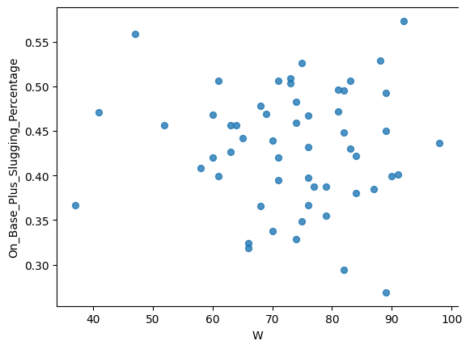

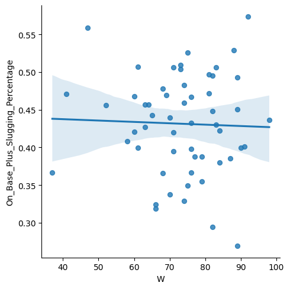

```python
batting_wins_year.plot(kind='scatter', x='W', y='On_Base_Plus_Slugging_Percentage', s=32, alpha=0.8)
plt.gca().spines[['right']].set_visible(False)
plt.gca().spines[['right']].set_visible(False)

sns.lmplot(x='W', y='On_Base_Plus_Slugging_Percentage', data=batting_wins_year, scatter_kws={'s': 32, 'alpha': 0.8})
plt.gca().spines['top'].set_visible(False)
plt.gca().spines['right'].set_visible(False)
plt.show()
```

Since the previous graphs did not show much correlation between wins and OPS, we can now create a box plot to see how much the OPS can vary for seasons with the same win totals. With this boxplot we are able to see that the majority of wins are grouped between 68 and 82 wins, just below average for a 162 game season. We can also see that the OPS for a team can vary greatly for the same win total. For example, for the seasons they won 75 games, the OPS has been as low as 0.34, but as high as 0.53, a very large difference.

[figure not shown]

```python
batting_wins_year.boxplot(column='On_Base_Plus_Slugging_Percentage', by='W', figsize=(8, 6), patch_artist=True)
plt.title('Box Plot of Earned Run Average by Wins')
plt.xlabel('Wins')
plt.ylabel('On_Base_Plus_Slugging')
plt.gca().spines['top'].set_visible(False)
plt.gca().spines['right'].set_visible(False)
plt.show()
```

Once again we are grouping the data by year, but this time we are using the pitching data. Now because we are focusing on pitching this time, we cannot use OPS, instead we use "Earned Run Average" or ERA. ERA represents the average number of runs a pitcher allows per 9 innings, so we will use this as our main defensive statistic.

```python
pitching_year=data_pitching.groupby('Year')['Earned_Run_Average'].mean().reset_index()
pitching_year.head()
```

|  | Year | Earned_Run_Average |
| --- | --- | --- |
| 0 | 1969 | 5.180000 |
| 1 | 1970 | 5.646875 |
| 2 | 1971 | 3.555000 |
| 3 | 1972 | 4.851333 |
| 4 | 1973 | 4.155000 |

Next, we again have to join our table with the wins per pear. We use a left join again on the year columns, and now we can compare ERA with Wins in order to see if there is an apparent correlation.

```python
pitching_wins_year = pd.merge(pitching_year, wins_year, on='Year', how='left')
pitching_wins_year.head()[["Year","Earned_Run_Average","W"]]
```

|  | Year | Earned_Run_Average | W |
| --- | --- | --- | --- |
| 0 | 1969 | 5.180000 | 52 |
| 1 | 1970 | 5.646875 | 63 |
| 2 | 1971 | 3.555000 | 61 |
| 3 | 1972 | 4.851333 | 58 |
| 4 | 1973 | 4.155000 | 60 |

Here, we are repeating the same stepsp we did for the previous data set. We graph the wins on the X axis and the ERA on th Y axis in order to create a scatter plot. However, once again, no relationship is readily available, so we must create a line of best fit. With the line of best fit added, we can see that there is downward slope. This means that the more games the team wins, the more likely the ERA is to be lower, or that the team will allow fewer runs. This makes sense.

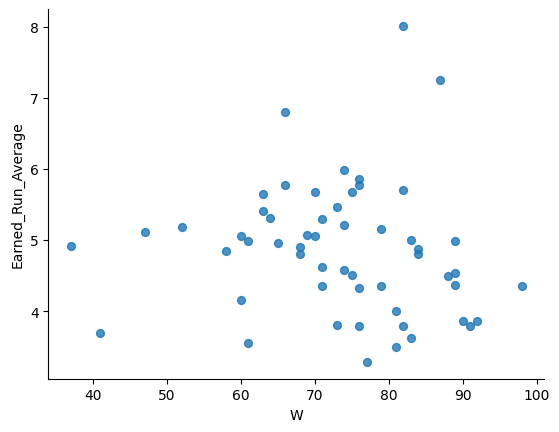

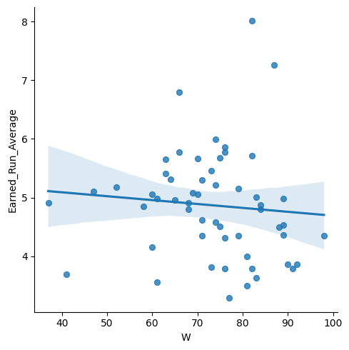

```python
pitching_wins_year.plot(kind='scatter', x='W', y='Earned_Run_Average', s=32, alpha=0.8)
plt.gca().spines[['top']].set_visible(False)
plt.gca().spines[['right']].set_visible(False)

sns.lmplot(x='W', y='Earned_Run_Average', data=pitching_wins_year, scatter_kws={'s': 32, 'alpha': 0.8})
plt.gca().spines['top'].set_visible(False)
plt.gca().spines['right'].set_visible(False)
plt.show()
```

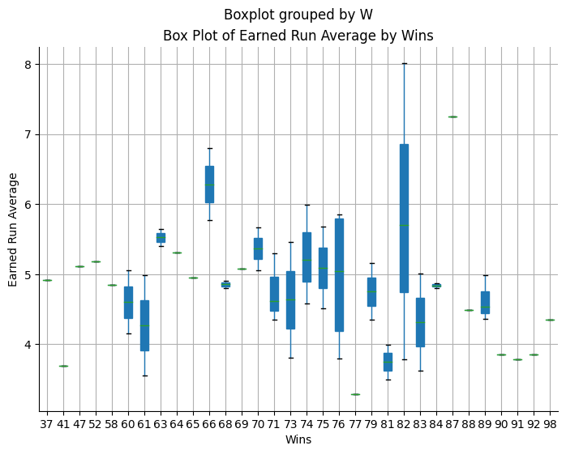

```python
pitching_wins_year.boxplot(column='Earned_Run_Average', by='W', figsize=(8, 6), patch_artist=True)
plt.title('Box Plot of Earned Run Average by Wins')
plt.xlabel('Wins')
plt.ylabel('Earned Run Average')
plt.gca().spines['top'].set_visible(False)
plt.gca().spines['right'].set_visible(False)
plt.show()
```

Now, to see how OPS and ERA are related, we can peform a left join by year on both the batting_year, and pitching_year dataframes. Since these dataframes are already grouped by year, no more grouping has to be done.

```python
batting_pitching=pd.merge(batting_year,pitching_year, on="Year",how="left")
batting_pitching.head(5)[["Year","Earned_Run_Average","On_Base_Plus_Slugging_Percentage"]]
```

|  | Year | Earned_Run_Average | On_Base_Plus_Slugging_Percentage |
| --- | --- | --- | --- |
| 0 | 1969 | 5.180000 | 0.456167 |
| 1 | 1970 | 5.646875 | 0.456649 |
| 2 | 1971 | 3.555000 | 0.506500 |
| 3 | 1972 | 4.851333 | 0.408073 |
| 4 | 1973 | 4.155000 | 0.468062 |

Now that we have these two dataframes joined together by year, we can create another scatterplot, this time with ERA on the X axis, and OPS on the Y axis. If we introduce a line of best fit, the relationship between ERA and OPS becomes apparent. Because the line of best fit slopes down from left to right, we can tell that as the ERA of a team increases, the OPS of a team will decrease. This essentially means that the worse the team is doing defensively, the worse they will do offensively.

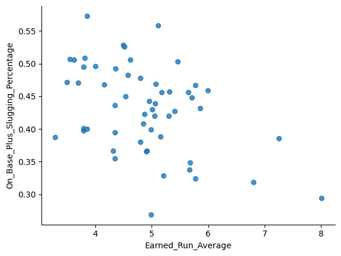

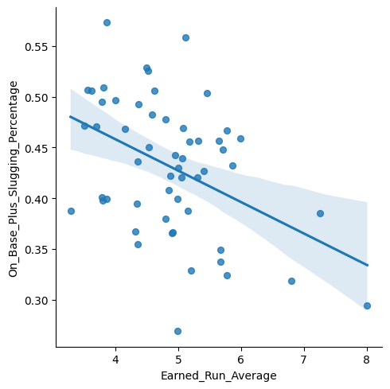

```python
batting_pitching.plot(kind='scatter', x='Earned_Run_Average', y='On_Base_Plus_Slugging_Percentage', s=32, alpha=.8)
plt.gca().spines[['top', 'right',]].set_visible(False)

sns.lmplot(x='Earned_Run_Average', y='On_Base_Plus_Slugging_Percentage', data=batting_pitching, scatter_kws={'s': 32, 'alpha': 0.8})
plt.gca().spines['top'].set_visible(False)
plt.gca().spines['right'].set_visible(False)
plt.show()
```

Next we want to see how these trends have changed over the years regarding the Padres. In order to see this, we will first split up the batting_wins_data set into two sections, the first half of the Padres existence, and the second half. In order to find this, we will start at the inception year, 1969, and then add half of the total years the team has existed to find the total range. This creates the first half group of years.

```python
Year_Range=[1969,1969+56/2]
batting_first_half=batting_wins_year[batting_wins_year['Year'].isin(range(1969,int(1969+56/2)))]
batting_first_half.head(2)
```

|  | Year | On_Base_Plus_Slugging_Percentage | Tm | Lg | G | W | L | Ties | W-L% | pythW-L% | ... | Playoffs | R | RA | Attendance | BatAge | PAge | #Bat | #P | Top Player | Managers |
| --- | --- | --- | --- | --- | --- | --- | --- | --- | --- | --- | --- | --- | --- | --- | --- | --- | --- | --- | --- | --- | --- |
| 0 | 1969 | 0.456167 | San Diego Padres | NL West | 162 | 52 | 110 | 0 | 0.321 | 0.299 | ... | NaN | 468 | 746 | 512970.0 | 26.2 | 24.9 | 42 | 17 | O.Brown (2.6) | P.Gómez (52-110) |
| 1 | 1970 | 0.456649 | San Diego Padres | NL West | 162 | 63 | 99 | 0 | 0.389 | 0.434 | ... | NaN | 681 | 788 | 643679.0 | 26.6 | 26.4 | 37 | 16 | C.Gaston (5.1) | P.Gómez (63-99) |

2 rows × 22 columns

```python
Year_Range_2=[1969+56/2,2023]
batting_second_half=batting_wins_year[batting_wins_year['Year'].isin(range(int(1969+56/2),2023))]
batting_second_half.head(2)
```

|  | Year | On_Base_Plus_Slugging_Percentage | Tm | Lg | G | W | L | Ties | W-L% | pythW-L% | ... | Playoffs | R | RA | Attendance | BatAge | PAge | #Bat | #P | Top Player | Managers |
| --- | --- | --- | --- | --- | --- | --- | --- | --- | --- | --- | --- | --- | --- | --- | --- | --- | --- | --- | --- | --- | --- |
| 28 | 1997 | 0.466844 | San Diego Padres | NL West | 162 | 76 | 86 | 0 | 0.469 | 0.448 | ... | NaN | 795 | 891 | 2089333.0 | 30.8 | 28.1 | 45 | 21 | T.Gwynn (4.3) | B.Bochy (76-86) |
| 29 | 1998 | 0.436262 | San Diego Padres | NL West | 162 | 98 | 64 | 0 | 0.605 | 0.575 | ... | Lost WS (4-0) | 749 | 635 | 2555874.0 | 31.1 | 29.8 | 42 | 21 | K.Brown (9.1) | B.Bochy (98-64) |

2 rows × 22 columns

Now that we have the batting data frame separated in half, we can graph it the same way we did before. After graphing, we can add a line of best fit and see that the line of best fit is once again almost perfectly horizontal. This leads us to believe that the number of wins did not greatly depend on the team OPS for the first half of the Padres existence.

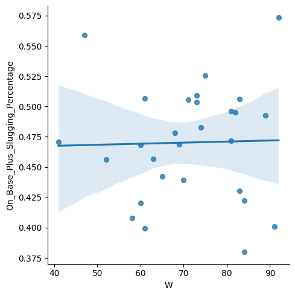

```python
sns.lmplot(x='W', y='On_Base_Plus_Slugging_Percentage', data=batting_first_half, scatter_kws={'s': 32, 'alpha': 0.8})
plt.gca().spines['top'].set_visible(False)
plt.gca().spines['right'].set_visible(False)
plt.show()
```

However, when we look at the graph for the second half of the Padres' existence we can see a different trend. With this graph's line of best fit there is a distinct positive slope. This means that throughout the second half of the Padres' existence, a higher OPS was more likely to lead to a higher win total.

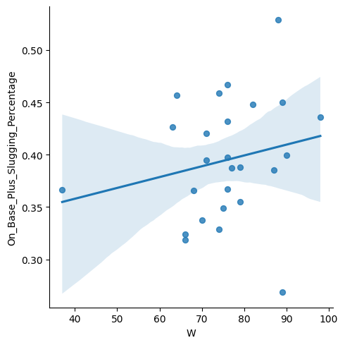

```python
sns.lmplot(x='W', y='On_Base_Plus_Slugging_Percentage', data=batting_second_half, scatter_kws={'s': 32, 'alpha': 0.8})
plt.gca().spines['top'].set_visible(False)
plt.gca().spines['right'].set_visible(False)
plt.show()
```

We once again compute the first half total, this time for the pitching data set. We use the same method we used for the batting, separating the years by the starting year and the halfway point.

```python
Year_Range=[1969,1969+56/2]
pitching_first_half=pitching_wins_year[pitching_wins_year['Year'].isin(range(1969,int(1969+56/2)))]
pitching_first_half.head(2)
```

|  | Year | Earned_Run_Average | Tm | Lg | G | W | L | Ties | W-L% | pythW-L% | ... | Playoffs | R | RA | Attendance | BatAge | PAge | #Bat | #P | Top Player | Managers |
| --- | --- | --- | --- | --- | --- | --- | --- | --- | --- | --- | --- | --- | --- | --- | --- | --- | --- | --- | --- | --- | --- |
| 0 | 1969 | 5.180000 | San Diego Padres | NL West | 162 | 52 | 110 | 0 | 0.321 | 0.299 | ... | NaN | 468 | 746 | 512970.0 | 26.2 | 24.9 | 42 | 17 | O.Brown (2.6) | P.Gómez (52-110) |
| 1 | 1970 | 5.646875 | San Diego Padres | NL West | 162 | 63 | 99 | 0 | 0.389 | 0.434 | ... | NaN | 681 | 788 | 643679.0 | 26.6 | 26.4 | 37 | 16 | C.Gaston (5.1) | P.Gómez (63-99) |

2 rows × 22 columns

Now we find the second half for the pitching data set by separating the pitching data set between the half way and 2023.

```python
Year_Range_2=[1969+56/2,2023]
pitching_second_half=pitching_wins_year[batting_wins_year['Year'].isin(range(int(1969+56/2),2023))]
pitching_second_half.head(2)
```

|  | Year | Earned_Run_Average | Tm | Lg | G | W | L | Ties | W-L% | pythW-L% | ... | Playoffs | R | RA | Attendance | BatAge | PAge | #Bat | #P | Top Player | Managers |
| --- | --- | --- | --- | --- | --- | --- | --- | --- | --- | --- | --- | --- | --- | --- | --- | --- | --- | --- | --- | --- | --- |
| 28 | 1997 | 5.774762 | San Diego Padres | NL West | 162 | 76 | 86 | 0 | 0.469 | 0.448 | ... | NaN | 795 | 891 | 2089333.0 | 30.8 | 28.1 | 45 | 21 | T.Gwynn (4.3) | B.Bochy (76-86) |
| 29 | 1998 | 4.351905 | San Diego Padres | NL West | 162 | 98 | 64 | 0 | 0.605 | 0.575 | ... | Lost WS (4-0) | 749 | 635 | 2555874.0 | 31.1 | 29.8 | 42 | 21 | K.Brown (9.1) | B.Bochy (98-64) |

2 rows × 22 columns

If we look at the first graph generated, representing the first half of the Padres' pitching throughout their years, we can see that once again, as the number of wins go up, the ERA of a time is much more likely to be lower.

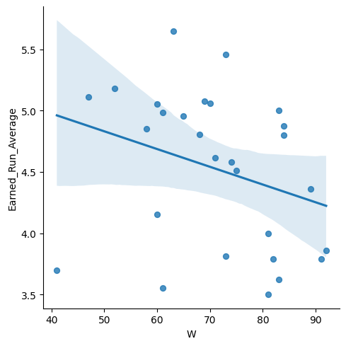

```python
sns.lmplot(x='W', y='Earned_Run_Average', data=pitching_first_half, scatter_kws={'s': 32, 'alpha': 0.8})
plt.gca().spines['top'].set_visible(False)
plt.gca().spines['right'].set_visible(False)
plt.show()
```

When looking at the second half of the Padres' pitching, we can see the same trend as we did in the first half. The line of best fit once again decreases from left to right, showing that the more wins the team gets, the more likely the ERA is to be lower.

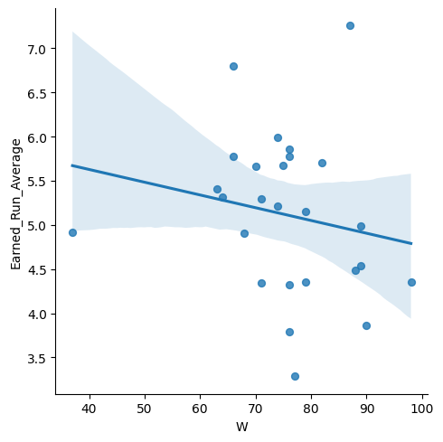

```python
sns.lmplot(x='W', y='Earned_Run_Average', data=pitching_second_half, scatter_kws={'s': 32, 'alpha': 0.8})
plt.gca().spines['top'].set_visible(False)
plt.gca().spines['right'].set_visible(False)
plt.show()
```

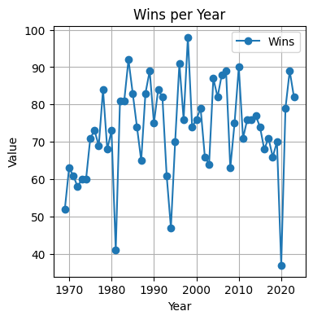

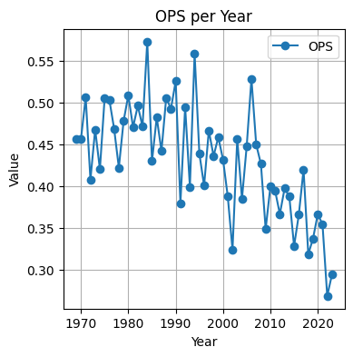

```python
plt.figure(figsize=(4 ,4))
plt.plot(batting_wins_year['Year'], batting_wins_year['W'], marker='o', label='Wins')
plt.title('Wins per Year')
plt.xlabel('Year')
plt.ylabel('Value')
plt.legend()
plt.grid(True)
plt.show()

plt.figure(figsize=(4, 4))
plt.plot(batting_wins_year['Year'], batting_wins_year['On_Base_Plus_Slugging_Percentage'], marker='o', label='OPS')
plt.title('OPS per Year')
plt.xlabel('Year')
plt.ylabel('Value')
plt.legend()
plt.grid(True)
plt.show()
```

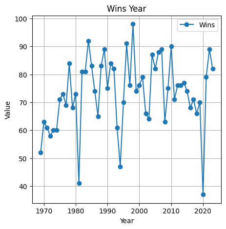

[figure not shown]

```python
plt.figure(figsize=(5, 5))
plt.plot(pitching_wins_year['Year'], pitching_wins_year['W'], marker='o', label='Wins')
plt.title('Wins Year')
plt.xlabel('Year')
plt.ylabel('Value')
plt.legend()
plt.grid(True)
plt.show()

plt.figure(figsize=(5, 5))
plt.plot(pitching_wins_year['Year'], pitching_wins_year['Earned_Run_Average'], marker='o', label='OPS')
plt.title('ERA per Year')
plt.xlabel('Year')
plt.ylabel('Value')
plt.legend()
plt.grid(True)
plt.show()
```